# Seminaroppgaver, STV4022, uke 2

Jørgen Bølstad

### Forberedelser

Last inn datasettet `attitude` ved å kjøre `data("attitude")`. Dette er data fra en liten survey av arbeidstakere i en stor organisasjon.

```r
data("attitude")
```

Legg analysene og svarene dine inn i et Rmd-dokument, slik at du kan levere inn en html-fil som både viser kodene dine, plottene dine, og svarene dine.

### Oppgave 1: Analytisk standardfeil og konfidensintervall

- Hva er gjennomsnittet for variabelen `rating`?

```r
mean(attitude$rating)
```

```
## [1] 64.63333
```

- Hva er standardavviket for variabelen?

```r
sd(attitude$rating)
```

```
## [1] 12.17256
```

- Hvor mange observasjoner er det i dataene?

```r
nrow(attitude)
```

```
## [1] 30
```

```r
# Vi kunne også sjekket hvor mange observasjoner som ikke er missing på variabelen vi er interesserte i:
sum(!is.na(attitude$rating))
```

```
## [1] 30
```

- Bruk løsningene på de to forrige spørsmålene over til å regne ut den analytiske (formel-baserte) standardfeilen til gjennomsnittet. Formelen finner du i notatene fra forelesning 3.

```r
# Standardfeilen = SD i utvalget / kvadratroten av antall observasjoner
sd_a <- sd(attitude$rating) / sqrt(nrow(attitude))
sd_a
```

```
## [1] 2.222396
```

- Bruk standardfeilen du regnet ut til å lage et tilnærmet 95%-konfidensintervall for gjennomsnittet. (Du kan anta at antallet observasjoner er høyt nok til at den kritiske t-verdien er ca. 2.)

```r
# Intervallet blir:
c(mean(attitude$rating) - 2*sd_a, # Nedre grense
  mean(attitude$rating) + 2*sd_a) # Øvre grense
```

```
## [1] 60.18854 69.07812
```

```r
# Merk: Vi kunne funnet den helt riktige t-verdien via den kvantil-funksjonen for t-fordelingen:
qt(.975, 30, 0) # Den nøyaktige verdien er egentlig litt over 2.
```

```
## [1] 2.042272
```

### Oppgave 2: Bootstrappet standardfeil og konfidensintervall

- Ta utgangspunkt i bootstrappings-koden fra kapittel 5 i pensumboken. (Denne koden ble også diskutert på forelesning 4.) Revidér koden slik at du kan bruke den til å bootstrappe standardfeilen til gjennomsnittet av `rating`-variabelen. Er den bootstrappede standarfeilen tilnærmet lik den analytiske?

```r
bootfun <- function(data){
  n <- nrow(data)
  boot <- sample(n, replace = TRUE)
  return(mean(data$rating[boot]))
}
n_sims <- 10000
output <- replicate(n_sims, bootfun(data = attitude))

# Den bootstrappede standardfeilen er:
sd(output) # Den er tilnærmet lik den analytiske
```

```
## [1] 2.199083
```

- Vis et histogram av den bootstrappede utvalgsfordelingen til gjennomsnittet.

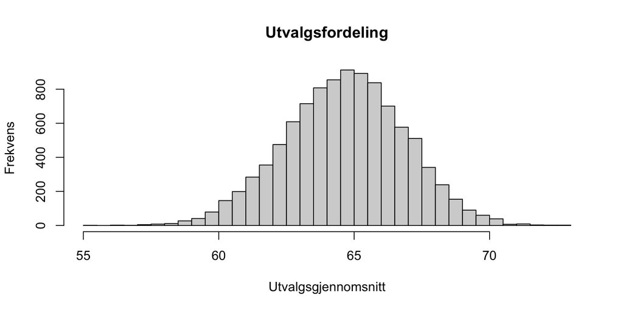

```r
hist(output, breaks = 50, main = "Utvalgsfordeling", xlab = "Utvalgsgjennomsnitt", ylab = "Frekvens")
```

- Hva blir 95%-konfidensintervallet hvis du baserer det på kvantiler av den bootstrappede utvalgsfordelingen?

```r
# Vi finner grensene som har 2.5% av resultatene under seg, og 97.5% over seg:
quantile(output, c(.025, .975))
```

```
##     2.5%    97.5%
## 60.26667 68.86667
```

### Oppgave 3: Bootstrappet standardfeil for medianen

- Hva er medianen til variabelen `rating`?

```r
median(attitude$rating)
```

```
## [1] 65.5
```

- Kjør en bootstrap-simulering for å estimere standardfeilen til medianen.

```r
bootfun <- function(data){
  n <- nrow(data)
  boot <- sample(n, replace = TRUE)
  return(median(data$rating[boot]))
}
n_sims <- 10000
output <- replicate(n_sims, bootfun(data = attitude))

# Den bootstrappede standardfeilen for medianen er:
sd(output)
```

```
## [1] 1.877614
```

- Vis et histogram av den bootstrappede utvalgsfordelingen til medianen.

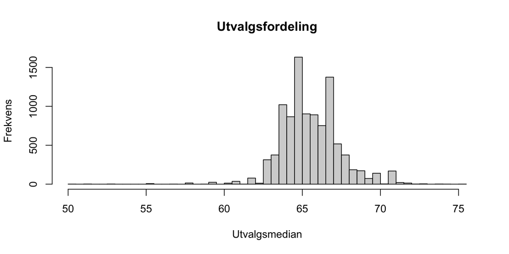

```r
hist(output, breaks = 50, main = "Utvalgsfordeling", xlab = "Utvalgsmedian", ylab = "Frekvens")
```

### Ekstraoppgave (oppgave 4): Simulering av sentralgrenseteoremet

I denne oppgaven skal du kjøre et sett simuleringer for å utforske sentralgrenseteoremet.

- Generér 2 tilfeldige observasjoner fra en flat fordeling hvor nedre grense er -10 og øvre grense er +10. (Dette kan gjøres via funksjonen `runif`. Bruk `help`-funksjonen for å se hvordan `runif`-funksjonen fungerer.)

```r
dat <- runif(n = 2, min = -10, max = 10)
dat
```

```
## [1]  4.919132 -8.542083
```

- Regn ut gjennomsnittet av dataene du genererer.

```r
mean(dat)
```

```
## [1] -1.811476
```

- Lag en kode som gir deg utvalgsfordelingen til gjennomsnittet, basert på 10000 simulerte datasett. (Dette kan f.eks. gjøres ved å lage en funksjon som genererer data og regner ut gjennomsnittet, og så bruke `replicate` for å gjenta denne funksjonen.)

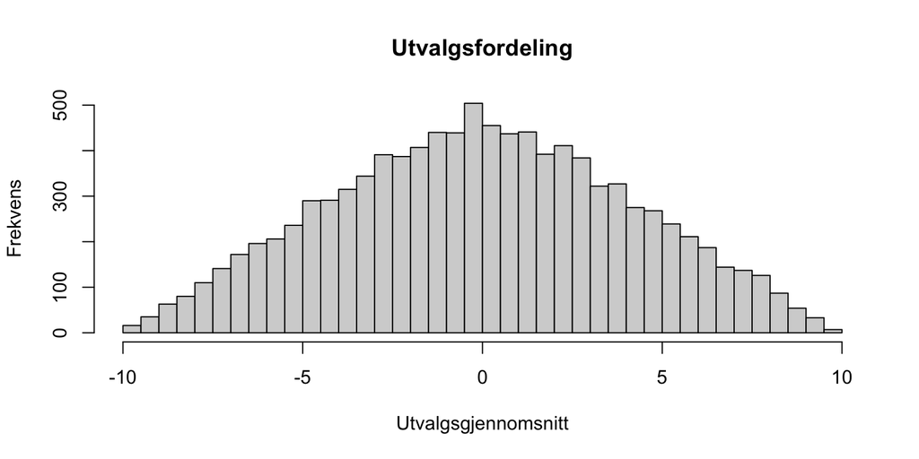

```r
# Lage en funksjon for å generere data og regne ut gjennomsnitt:
get_mean <- function(n = 2) { # Her er n = 2 satt som standard, hvis n ikke spesifiseres
  dat <- runif(n = n, min = -10, max = 10)
  mean(dat)
}

# Gjenta funksjonen 10000 ganger:
output <- replicate(10000, get_mean()) # Trenger ikke spesifisere n i get_mean, siden n ble satt som standard

# Oppsummere resultatene i et histogram
hist(output, breaks = 35, main = "Utvalgsfordeling", xlab = "Utvalgsgjennomsnitt", ylab = "Frekvens")
```

- Start med å simulere kun 2 datapunkter i hvert datasett, og kjør så nye simuleringer hvor du øker antall datapunkter. Hvor mange observasjoner kreves det før utvalgsfordelingen til gjennomsnittet er tilnærmet normalfordelt?

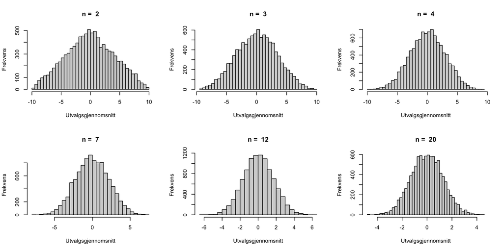

```r
# For å få litt bedre oversikt kan vi sette sammen plottene vi skal lage
par(mfrow = c(2, 3)) # Dette gjør at plottene tegnes i rutenett på 2x3

# Å lage histogrammer for ulike antall observasjoner kan gjøres slik:
# hist(replicate(10000, get_mean(2)), breaks = 35)
# hist(replicate(10000, get_mean(3)), breaks = 35)
# hist(replicate(10000, get_mean(4)), breaks = 35)
# hist(replicate(10000, get_mean(5)), breaks = 35)
# hist(replicate(10000, get_mean(7)), breaks = 35)
# hist(replicate(10000, get_mean(10)), breaks = 35)

# En alternativ måte å gjøre det på, er slik:
for (n in c(2, 3, 4, 7, 12, 20)) { # Loop gjennom de ulike antall obsvervasjoner vi ønsker
  hist(replicate(10000, get_mean(n)),
       breaks = 35,             # Spesifiser antall celler i histogrammet
       main = paste("n = ", n), # Legg til en tittel som inneholder antall observasjoner
       xlab = "Utvalgsgjennomsnitt", # Legg til et navn for x-aksen
       ylab = "Frekvens")       # Legg til et navn for y-aksen
}
```

### Ekstraoppgave (oppgave 5): Simulering av estimator-egenskaper

- Lag en funksjon for å estimere standardavvik. Formelen finner du i notatene fra forelesning 1. La funksjonen dele på $n$ istedet for $n - 1$. (Du kan finne antall observasjoner i en vektor ved å bruke `length`-funksjonen.)

```r
sd_func <- function(x) {
  sqrt(sum((x - mean(x))^2) / length(x))
}
```

- Lag så en funksjon som:
  - Generer 5 datapunkter fra en normalfordeling med gjennomsnitt 0 og standardavvik 1.
  - Estimerer standardavviket for disse dataene via funksjonen du lagde tidligere.
  - Returnerer dette standardavviket

```r
get_sd <- function(n = 5) { # Setter n = 5 som standard, men åpner for å spesifisere andre verdier
  dat <- rnorm(n, mean = 0, sd = 1)
  sd_out <- sd_func(dat)
  return(sd_out)
}
```

- Replikér funksjonen 10000 ganger for å estimere utvalgsfordelingen for standardavviks-estimatoren din. Vis et histogram av fordelingen.

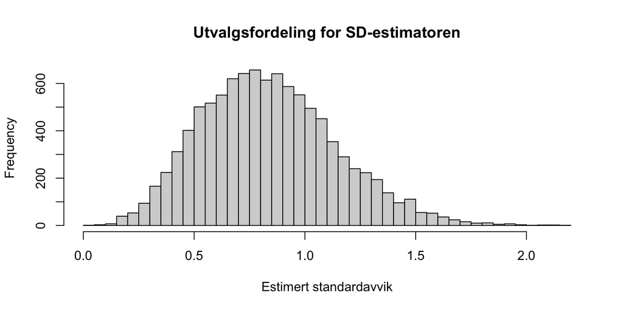

```r
output <- replicate(10000, get_sd())
hist(output, breaks = 35, main = "Utvalgsfordeling for SD-estimatoren", xlab = "Estimert standardavvik")
```

- Regn ut gjennomsnittet av fordelingen. Er estimatoren din forventningsrett (“unbiased”)?

```r
mean(output) # Nei, den er ikke forventningsrett
```

```
## [1] 0.8381773
```

- Kjør et tilsvarende sett simuleringer med 1000 observasjoner i hvert datasett. Ser estimatoren din ut til å være konsistent?

```r
output <- replicate(10000, get_sd(1000))
mean(output) # Ja, nå er gjennomsnittet av fordelingen tilnærmet riktig
```

```
## [1] 0.9990768
```